# Projekt - Szeregi czasowe

Maja Dulniak

2023-01-28

```r
library(tinytex)
library(tseries)
library(tidyverse)
library(flextable)
library(rstatix)
library(corrplot)
library(forecast)
library(randtests)
library(nortest)
library(lmtest)
```

*W projekcie przeprowadziłam analizę dwóch kursów walut : brytyjskiej oraz chińskiej.*

Żródło danych :

https://finance.yahoo.com/quote/CNYUSD=X?p=CNYUSD=X&.tsrc=fin-srch

https://finance.yahoo.com/quote/GBPUSD%3DX?p=GBPUSD%3DX

# Kurs waluty brytyjskiej GBP

**1.Opisać oraz wyznaczyć podstawowe statystyki. Narysować histogram oraz “box-plot”. Wyznaczyć wartości funkcji autokorelacji dla t = 0, 1, . . . , 50.**

```r
GBP<- get.hist.quote(instrument = "GBPUSD=X", provider = "yahoo",
                         quote = "Close", start = "2022-01-03",
                         end = "2022-12-30")
GBP <- as.numeric(GBP)
```

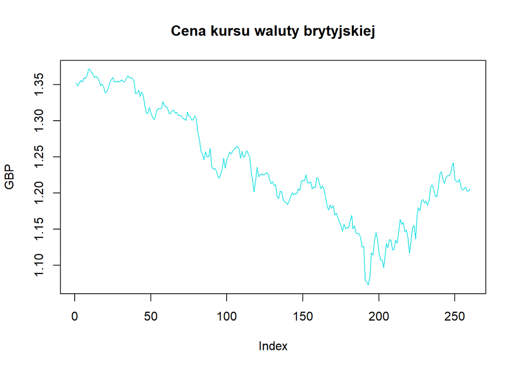

```r
plot(GBP,  col=5, main="Cena kursu waluty brytyjskiej", type="l")
```

```r
GBP <- na.omit(GBP)
```

## Statystyki opisowe

- Wartość maksymalna

```r
max(GBP)
```

```
## [1] 1.371366
```

- Wartość minimalna

```r
min(GBP)
```

```
## [1] 1.072754
```

- Średnia

```r
mean(GBP)
```

```
## [1] 1.237177
```

- Mediana

```r
median(GBP)
```

```
## [1] 1.223122
```

- Kwantyl dolny

```r
quantile(GBP,0.25)
```

```
##      25%
## 1.186289
```

- Kwantyl górny

```r
quantile(GBP,0.75)
```

```
##      75%
## 1.308147
```

- Odchylenie standardowe

```r
sd(GBP)
```

```
## [1] 0.07626574
```

- Wariancja

```r
var(GBP)
```

```
## [1] 0.005816462
```

## Histogram

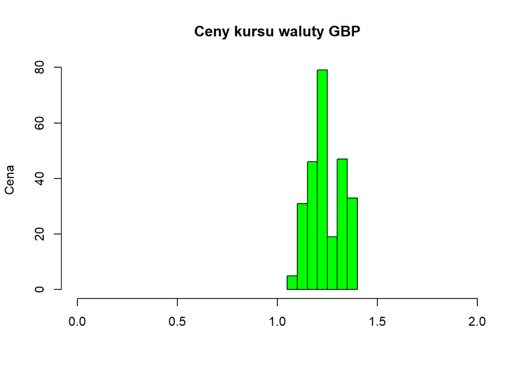

```r
hist(GBP,
     main = "Ceny kursu waluty GBP",
     col = "green",
     border = "black",
     xlim = c(0,2),
     breaks = 10,
     xlab="",
     ylab="Cena",
     prob=FALSE)
```

## Wykres ramka-wąsy

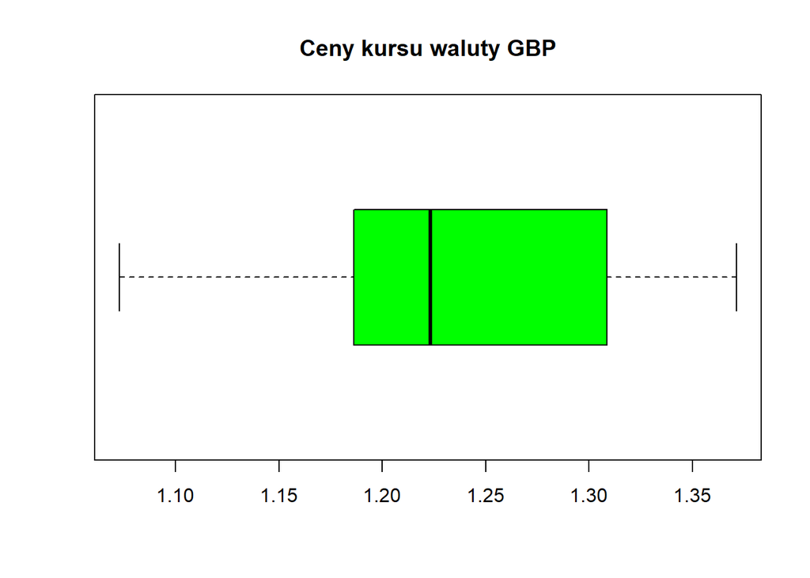

```r
boxplot(GBP,
        main = "Ceny kursu waluty GBP",
        col = "green",
        border = "black",
        horizontal = TRUE)
```

## Funkcja autokorelacji

Wyznaczenie poszczególnych wartości funkcji autokorelacji dla t = 0,1,…,50.

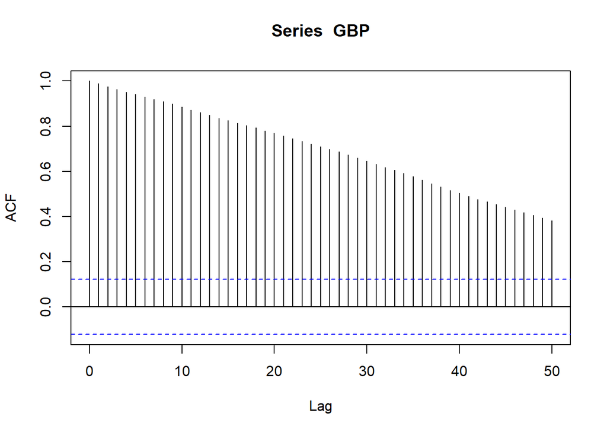

```r
wsp_a <- acf(GBP, pl=FALSE, lag= 50)
plot(wsp_a)
```

Autokorelacja dla t=0 jest równa 1.

Dla t=50 jest równa 0.382.

Im większy moduł ze współczynnika autokorelacji, tym silniejszy jest związek między elementami szeregu czasowego podstawowego i przesuniętego w czasie o t.

**2.Wyznaczyć dekompozycję Holta-Wintersa. Przedstawić wykres. Dokonać predykcji na kolejne 10 notowań.**

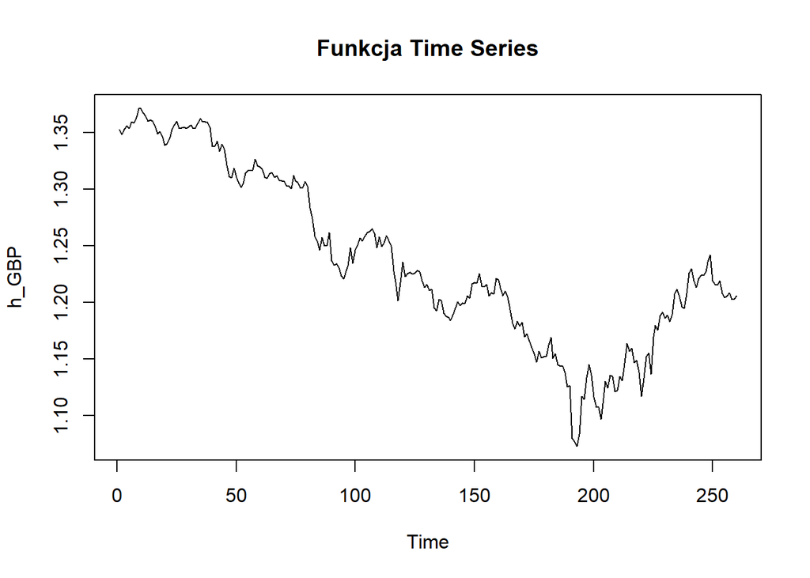

```r
h_GBP <- ts(GBP,frequency=1)
plot(h_GBP, main="Funkcja Time Series")
```

Nie występuje sezonowość na wykresie, dlatego skorzystamy z metody dekompozycji Holta-Wintersa.

## Dekompozycja Holta-Wintersa

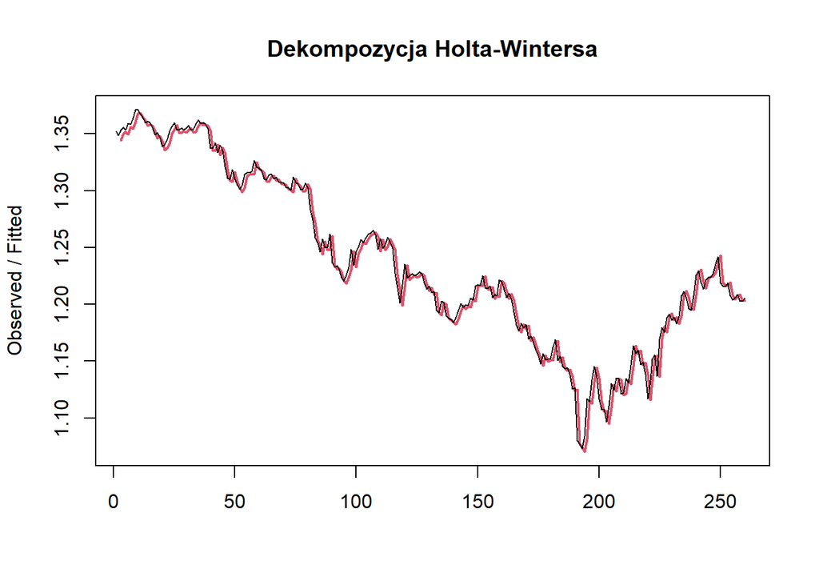

```r
dekompozycja <- HoltWinters(h_GBP,gamma = FALSE)
plot(dekompozycja, lwd=2, main = "Dekompozycja Holta-Wintersa", xlab="")
```

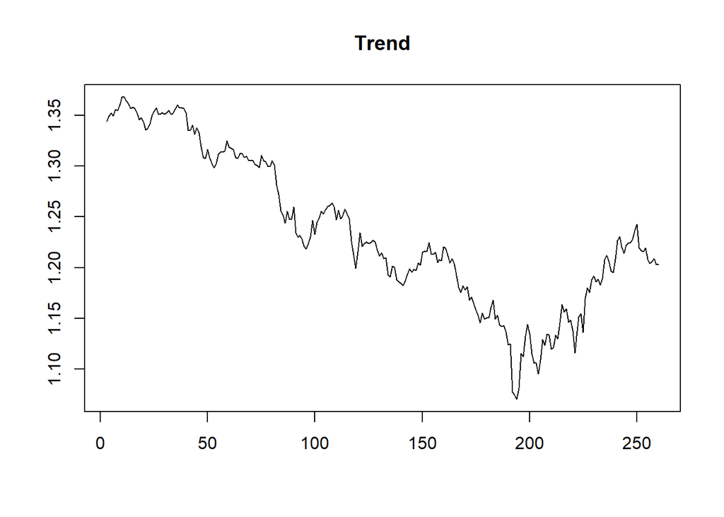

```r
trend <- dekompozycja$fitted[,1]
plot(trend, col="black", xlab=" ", ylab=" ", main="Trend")
```

## Predykcja

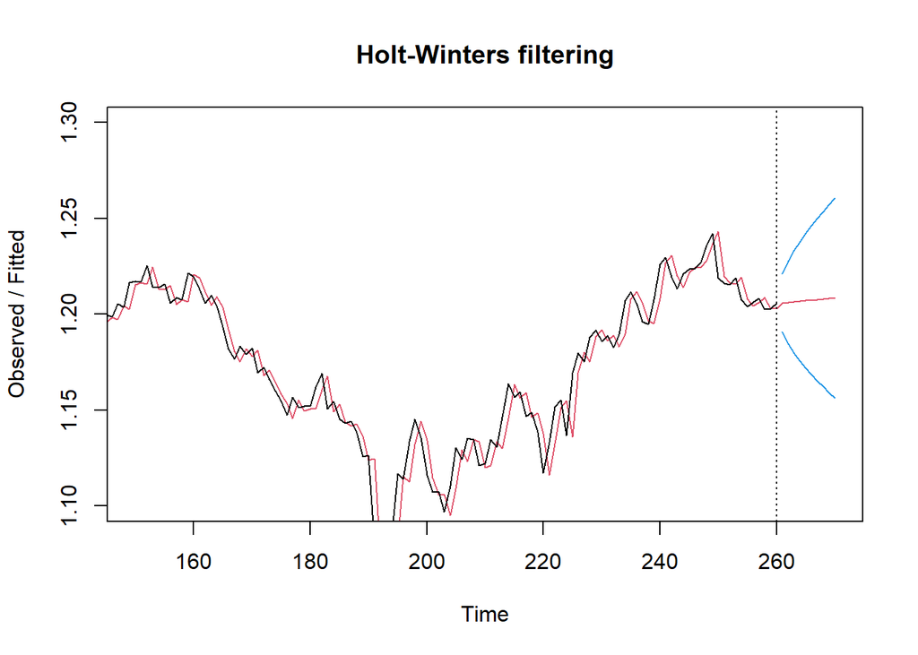

```r
p <- predict(dekompozycja, n.ahead = 10, prediction.interval = TRUE, level = 0.9)

plot(dekompozycja, p, xlim = c(150,270), ylim = c(1.1,1.3))
```

Czerwona linia na wykresie oznacza wartość oczekiwaną.

Niebieskie linie - pierwsza i trzecia wartość przy poziomie ufności 0.9

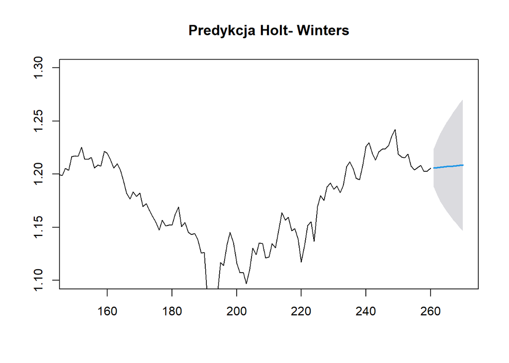

```r
plot(forecast(dekompozycja, level = c(95), h=10),xlim = c(150,270), ylim = c(1.1,1.3), main = "Predykcja Holt- Winters")
```

**3.Trend występujący w szeregu czasowym dopasować wielomianem odpowiedniego stopnia. Uzasadnić wybór stopnia wielomianu. Przedstawić wykres zachowania analizowanej cechy oraz dopasowanie uzyskane za pomocą regresji wielomianowej. Dokonać analizy szeregu reszt (test niezależności, normalności reszt, jednorodności wariancji). Zinterpretować wyniki.**

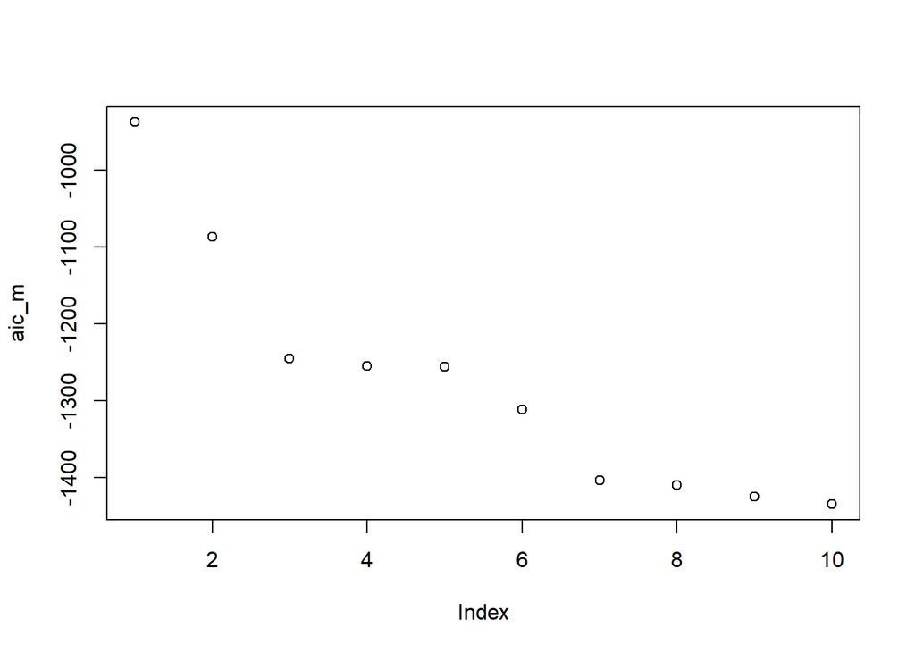

```r
t <- 1:length(GBP)
aic_m <- AIC(lm(GBP~t))

for(j in 2:10){
macierz <- NULL
for (k in 1:j) {
macierz <- cbind(macierz, t^k)
}
colnames(macierz) <- paste0("t^", 1:j)
mod <- lm(GBP~macierz)
aic_m <- c(aic_m, AIC(mod))
}

plot(aic_m)
```

Wybieramy wielomian stopnia 7.

```r
t <- 1:length(trend)

mod7 <- lm(trend~t + I(t^2) + I(t^3) + I(t^4) + I(t^5)+ I(t^6)+I(t^7))
wsp7 <- coef(mod7)
predict7 <- wsp7[1]+wsp7[2]*t+wsp7[3]*t^2+wsp7[4]*t^3+wsp7[5]*t^4+wsp7[6]*t^5+wsp7[7]*t^6+wsp7[8]*t^7
predict77 <- mod7$fitted.values
max(abs(wsp7[1]+wsp7[2]*t+wsp7[3]*t^2+wsp7[4]*t^3+wsp7[5]*t^4+wsp7[6]*t^5+wsp7[7]*t^6+wsp7[8]*t^6 - mod7$fitted.values))
```

```
## [1] 140.4455
```

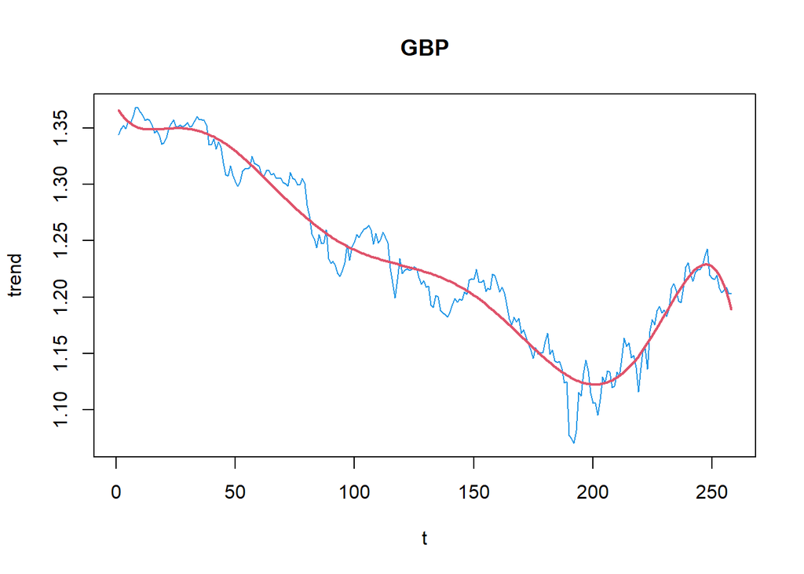

```r
plot(t,trend, col = 4, main = "GBP", type = "l")
lines(t, predict77, col = 2, lwd = 2)
```

- Test niezależności

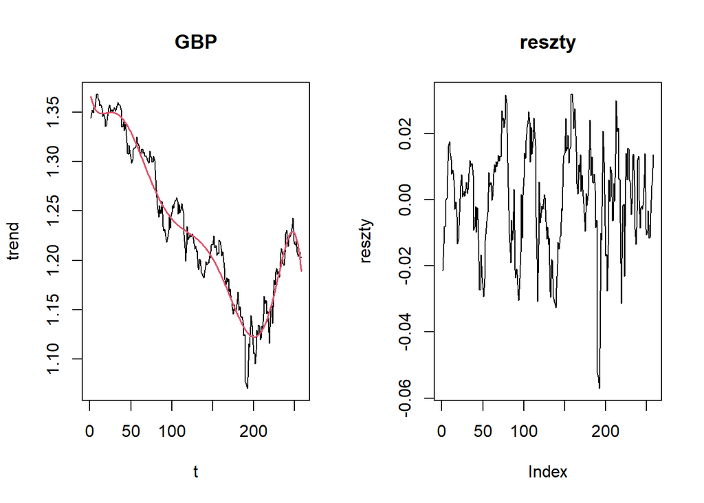

```r
library(tidyverse)
model1 <- lm(trend~t + I(t^2) + I(t^3) + I(t^4) + I(t^5) + I(t^6) + I(t^7))
reszty <- model1$residuals

par(mfrow=c(1,2))
plot(t,trend, type="l", main="GBP")
lines(t, model1$fitted.values, col=2, lwd=1.5)

plot(reszty, type="l", main="reszty")
```

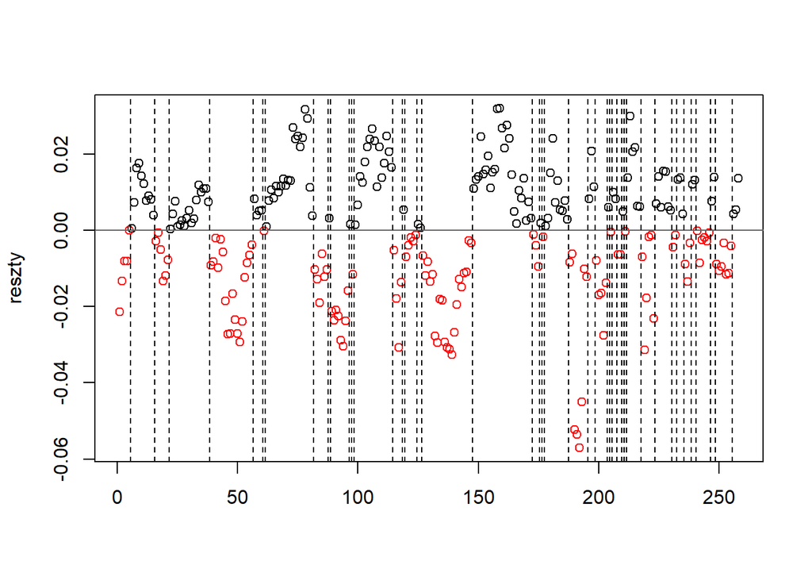

```
##
##  Runs Test
##
## data:  reszty
## statistic = -10.703, runs = 44, n1 = 138, n2 = 120, n = 258, p-value <
## 2.2e-16
## alternative hypothesis: nonrandomness
```

```r
#abline(h=0, col=2, lwd=1.5)
par(mfrow=c(1,1))

runs.test(reszty, alternative = "two.sided", threshold=0, plot=T)
```

```r
Box.test(reszty, lag=5, type="Ljung") #występuje korelacja
```

```
##
##  Box-Ljung test
##
## data:  reszty
## X-squared = 410.11, df = 5, p-value < 2.2e-16
```

```r
Box.test(reszty, lag=10, type="Ljung") #występuje korelacja
```

```
##
##  Box-Ljung test
##
## data:  reszty
## X-squared = 429.69, df = 10, p-value < 2.2e-16
```

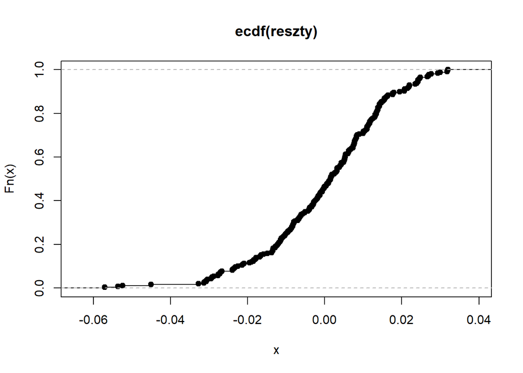

```r
plot(ecdf(reszty))
```

Odrzucamy H0. Reszty modelu są zależne.

- Test normalności reszt

```r
library(olsrr)
library(stats)
ols_test_normality(reszty)
```

```
## -----------------------------------------------
##        Test             Statistic       pvalue
## -----------------------------------------------
## Shapiro-Wilk              0.9764          3e-04
## Kolmogorov-Smirnov        0.0485         0.5776
## Cramer-von Mises         83.3193         0.0000
## Anderson-Darling          1.1367         0.0056
## -----------------------------------------------
```

Testy Andersona i Shapiro-Wilka potwierdzają,że odrzucamy hipotezę zerową, czyli nie jest to rozkład normalny. Więc występuje wewnętrzna zależność.

Badanie jednorodności nie jest konieczne. Przypuszczamy, że wariancje są jednorodne.

**4.W zależności od otrzymanych wyników w p. 3, dokonać identyfikacji szeregu reszt (np.ciąg niezależnych zmiennych losowych, ARIMA, GARCH).**

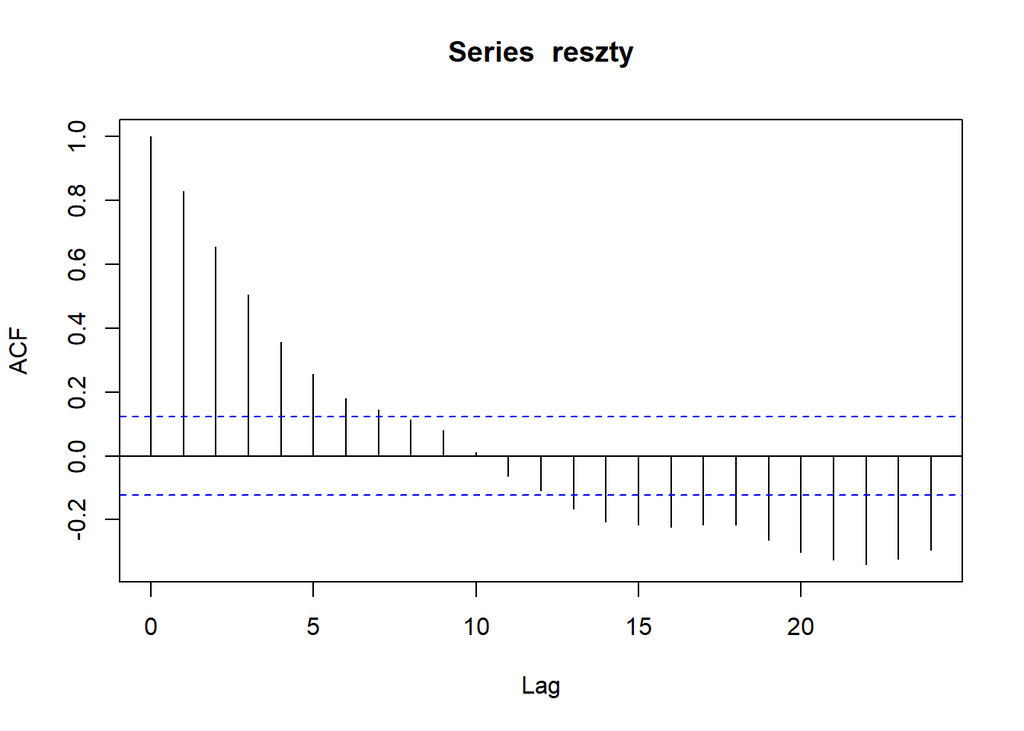

```r
acf(reszty)
```

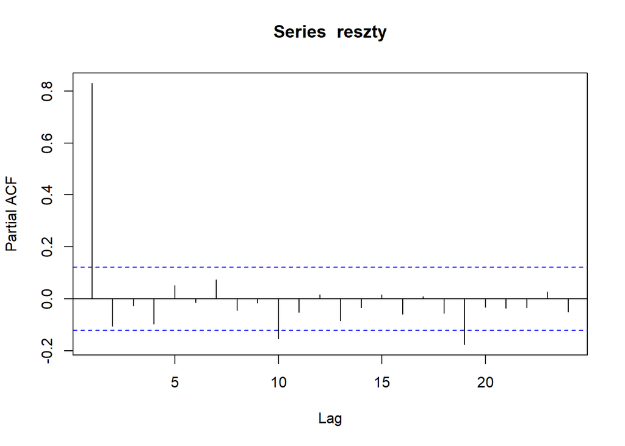

```r
pacf(reszty)
```

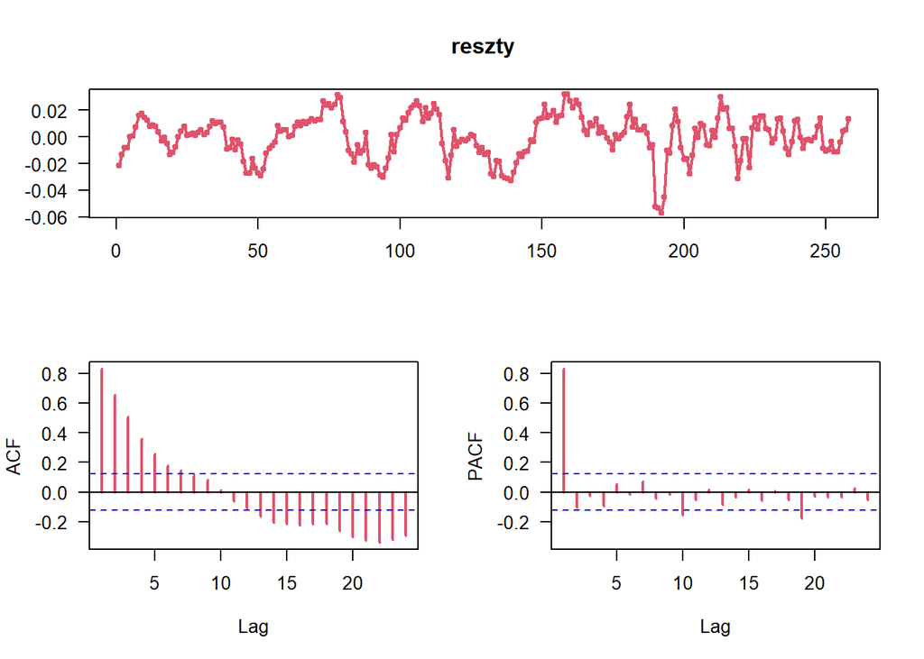

```r
tsdisplay(reszty, col=2, lwd=2, las=1)
```

W badanych wartościach występuje trend , ponieważ funkcja autokorelacji maleje.

Różnicowanie na resztach:

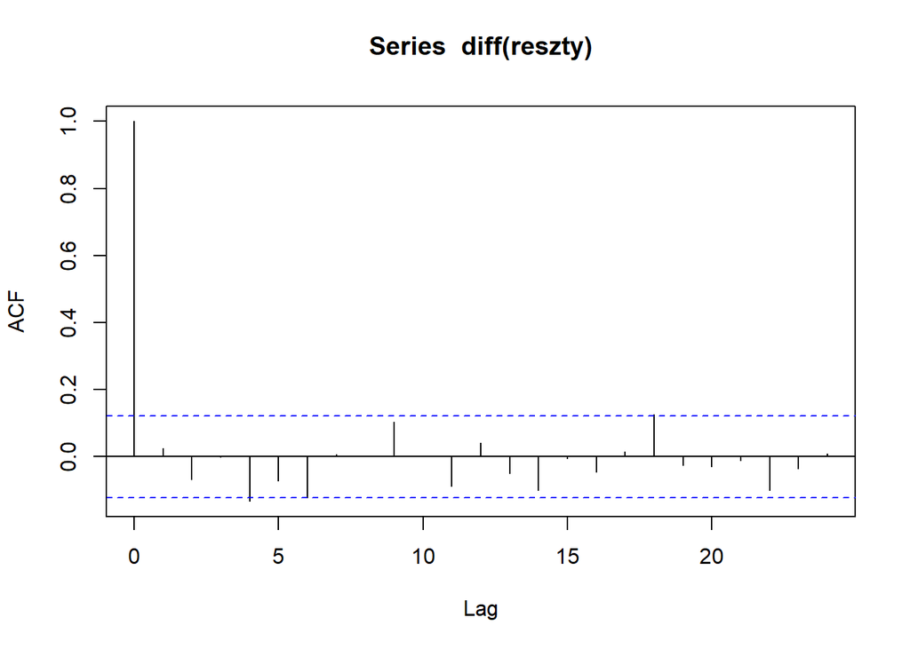

```r
acf(diff(reszty))
```

## Model ARIMA

```r
arima1 <- auto.arima(diff(reszty), ic="aic", trace = TRUE, seasonal=F)
```

```
##
##  Fitting models using approximations to speed things up...
##
##  ARIMA(2,0,2) with non-zero mean : Inf
##  ARIMA(0,0,0) with non-zero mean : -1675.816
##  ARIMA(1,0,0) with non-zero mean : -1673.707
##  ARIMA(0,0,1) with non-zero mean : -1673.989
##  ARIMA(0,0,0) with zero mean     : -1677.76
##  ARIMA(1,0,1) with non-zero mean : Inf
##
##  Now re-fitting the best model(s) without approximations...
##
##  ARIMA(0,0,0) with zero mean     : -1677.76
##
##  Best model: ARIMA(0,0,0) with zero mean
```

```r
arima1 <- auto.arima(diff(reszty))
arima1
```

```
## Series: diff(reszty)
## ARIMA(0,0,0) with zero mean
##
## sigma^2 = 8.491e-05:  log likelihood = 839.88
## AIC=-1677.76   AICc=-1677.74   BIC=-1674.21
```

```r
#arima1$model1$phi
#arima1$model1$theta
#arima1$model1$delta
```

5.Zbadać stacjonarność szeregu badanej cechy. Dokonać identyfikacji za pomocą modeli.

Stacjonarność szeregu

```r
adf.test(GBP)
```

```
##
##  Augmented Dickey-Fuller Test
##
## data:  GBP
## Dickey-Fuller = -0.74292, Lag order = 6, p-value = 0.9658
## alternative hypothesis: stationary
```

```r
kpss.test(GBP)
```

```
##
##  KPSS Test for Level Stationarity
##
## data:  GBP
## KPSS Level = 3.6209, Truncation lag parameter = 5, p-value = 0.01
```

```r
pp.test(GBP)
```

```
##
##  Phillips-Perron Unit Root Test
##
## data:  GBP
## Dickey-Fuller Z(alpha) = -4.7688, Truncation lag parameter = 5, p-value
## = 0.8428
## alternative hypothesis: stationary
```

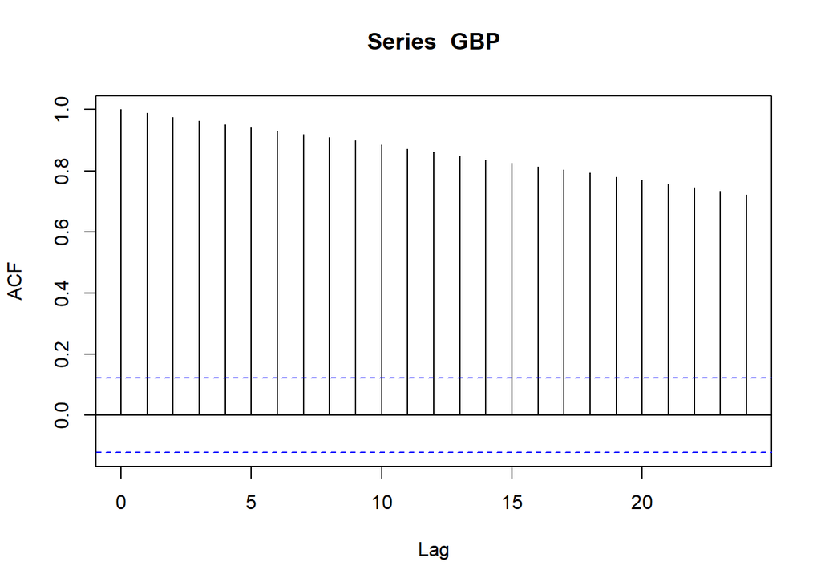

```r
acf(GBP)
```

Na podstawie testów widzimy ,że szereg nie jest stacjonarny.

```r
adf.test(diff(GBP))
```

```
##
##  Augmented Dickey-Fuller Test
##
## data:  diff(GBP)
## Dickey-Fuller = -6.8253, Lag order = 6, p-value = 0.01
## alternative hypothesis: stationary
```

```r
kpss.test(diff(GBP))
```

```
##
##  KPSS Test for Level Stationarity
##
## data:  diff(GBP)
## KPSS Level = 0.18671, Truncation lag parameter = 5, p-value = 0.1
```

```r
pp.test(diff(GBP))
```

```
##
##  Phillips-Perron Unit Root Test
##
## data:  diff(GBP)
## Dickey-Fuller Z(alpha) = -231.56, Truncation lag parameter = 5, p-value
## = 0.01
## alternative hypothesis: stationary
```

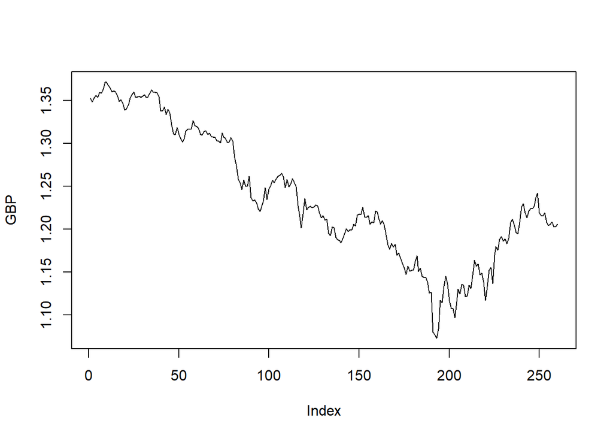

```r
plot(GBP, type = "l")
```

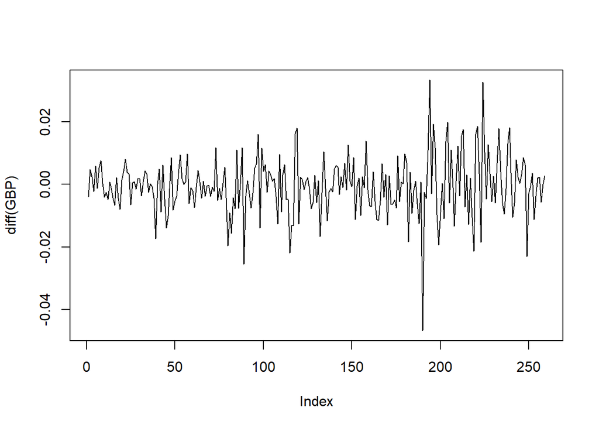

```r
plot(diff(GBP), type = "l")
```

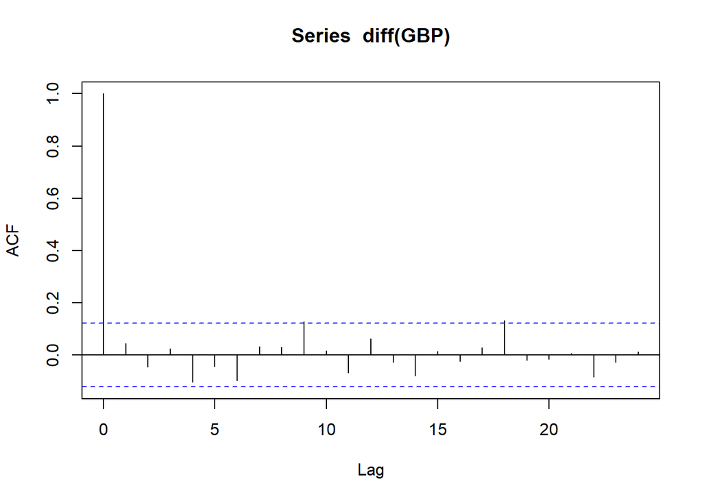

```r
acf(diff(GBP))
```

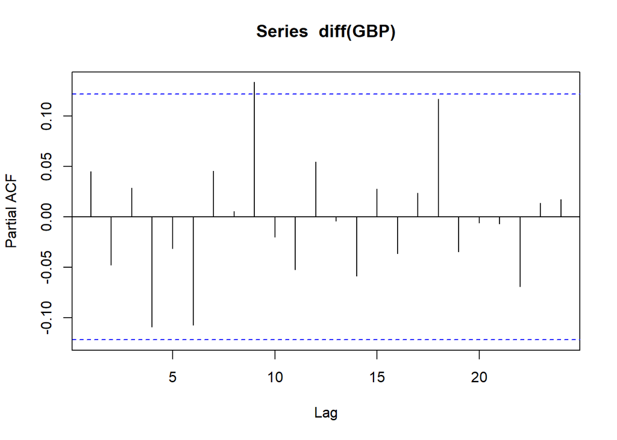

```r
pacf(diff(GBP))
```

Identyfikacja za pomocą modeli klasy ARIMA.

```r
auto.arima(diff(GBP), ic="aic", trace = TRUE, seasonal=F)
```

```
##
##  Fitting models using approximations to speed things up...
##
##  ARIMA(2,0,2) with non-zero mean : -1689.831
##  ARIMA(0,0,0) with non-zero mean : -1695.321
##  ARIMA(1,0,0) with non-zero mean : -1692.98
##  ARIMA(0,0,1) with non-zero mean : -1693.903
##  ARIMA(0,0,0) with zero mean     : -1696.321
##  ARIMA(1,0,1) with non-zero mean : -1694.168
##
##  Now re-fitting the best model(s) without approximations...
##
##  ARIMA(0,0,0) with zero mean     : -1696.321
##
##  Best model: ARIMA(0,0,0) with zero mean
```

```
## Series: diff(GBP)
## ARIMA(0,0,0) with zero mean
##
## sigma^2 = 8.313e-05:  log likelihood = 849.16
## AIC=-1696.32   AICc=-1696.31   BIC=-1692.76
```

```r
a <- auto.arima(diff(GBP))
a
```

```
## Series: diff(GBP)
## ARIMA(0,0,0) with zero mean
##
## sigma^2 = 8.313e-05:  log likelihood = 849.16
## AIC=-1696.32   AICc=-1696.31   BIC=-1692.76
```

```r
#a$model1$phi
#a$model1$theta
#a$model1$Delta

auto.arima(diff(GBP))
```

```
## Series: diff(GBP)
## ARIMA(0,0,0) with zero mean
##
## sigma^2 = 8.313e-05:  log likelihood = 849.16
## AIC=-1696.32   AICc=-1696.31   BIC=-1692.76
```

```r
arima(diff(GBP), order = c(0,0,0))
```

```
##
## Call:
## arima(x = diff(GBP), order = c(0, 0, 0))
##
## Coefficients:
##       intercept
##          -6e-04
## s.e.      6e-04
##
## sigma^2 estimated as 8.281e-05:  log likelihood = 849.66,  aic = -1695.32
```

# Kurs waluty chińskiej CNY

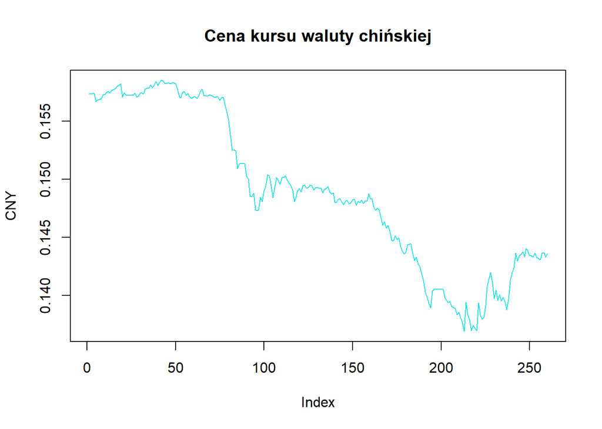

```r
CNY<- get.hist.quote(instrument = "CNYUSD=X", provider = "yahoo", quote = "Close", start = "2022-01-03", end = "2022-12-30")
CNY <- as.numeric(CNY)

plot(CNY,  col=5, main="Cena kursu waluty chińskiej", type="l")
```

```r
CNY<-na.omit(CNY)
```

## Statystyki opisowe

- wartość maksymalna

```r
max(CNY)
```

```
## [1] 0.1585188
```

- wartość minimalna

```r
min(CNY)
```

```
## [1] 0.136915
```

- Średnia

```r
mean(CNY)
```

```
## [1] 0.148907
```

- Mediana

```r
median(CNY)
```

```
## [1] 0.1486646
```

- Kwantyl dolny

```r
quantile(CNY, 0.25)
```

```
##       25%
## 0.1434247
```

- Kwantyl górny

```r
quantile(CNY, 0.75)
```

```
##      75%
## 0.157066
```

- Odchylenie standardowe

```r
sd(CNY)
```

```
## [1] 0.006740793
```

- Wariancja

```r
var(CNY)
```

```
## [1] 4.54383e-05
```

## Histogram

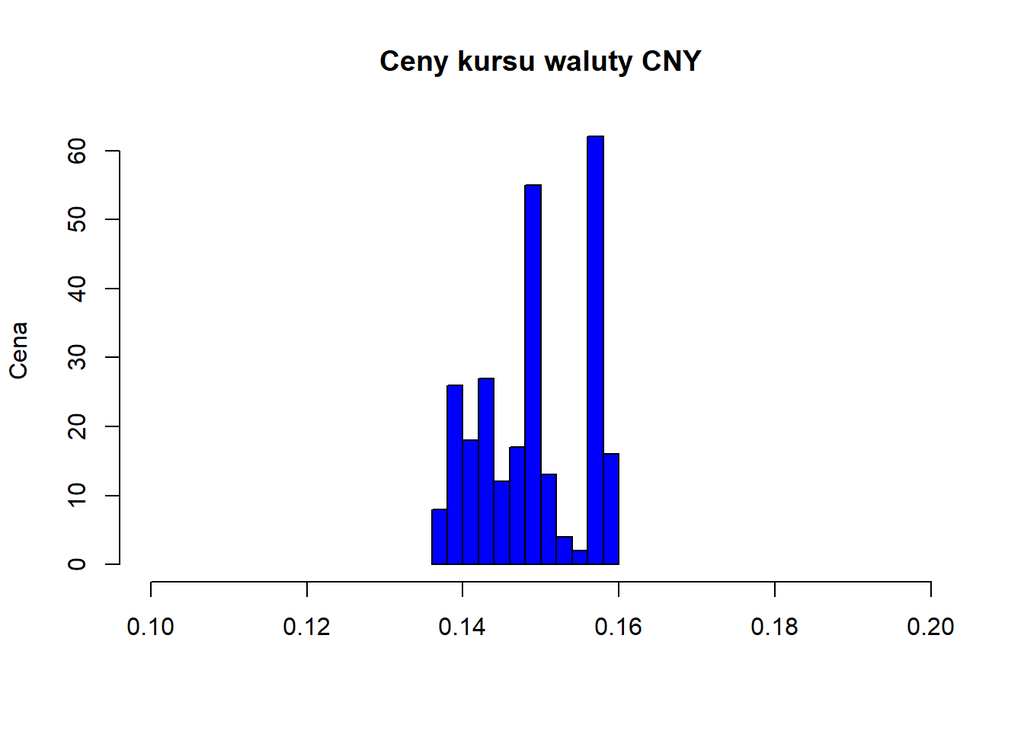

```r
hist(CNY,
     main = "Ceny kursu waluty CNY",
     col = "blue",
     border = "black",
     xlim = c(0.1,0.2),
     breaks = 10,
     xlab="",
     ylab="Cena",
     prob=FALSE)
```

## Wykres ramka-wąsy

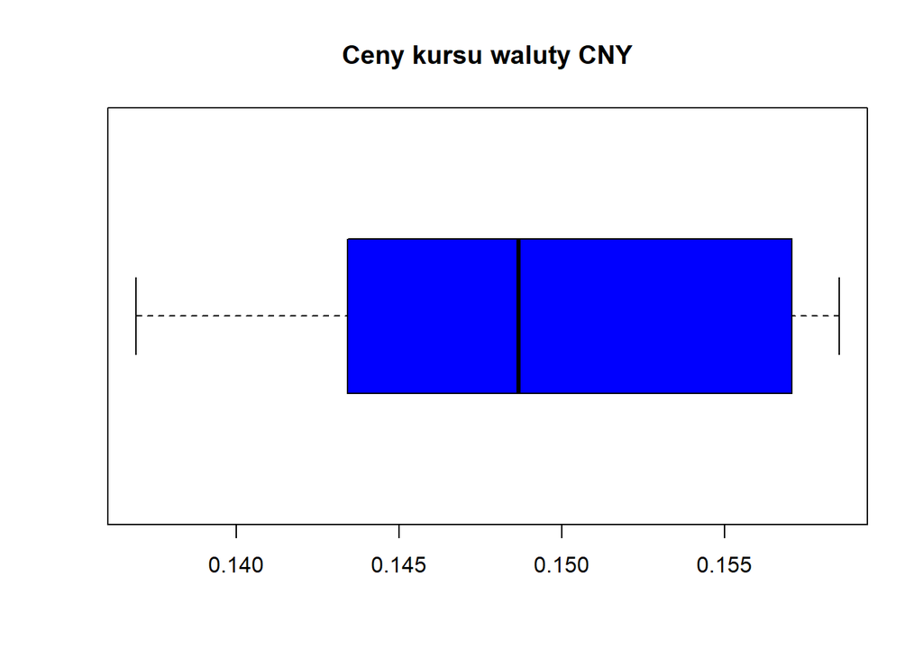

```r
boxplot(CNY,
        main = "Ceny kursu waluty CNY",
        col = "blue",
        border = "black",
        horizontal = TRUE)
```

## Funkcja autokorelacji

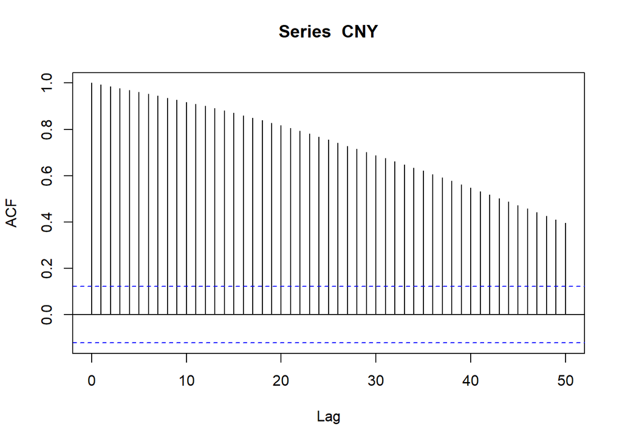

```r
wsp_a2<-acf(CNY, pl=FALSE, lag= 50)
plot(wsp_a2)
```

```r
acf(CNY, pl=FALSE, lag= 50)
```

```
##
## Autocorrelations of series 'CNY', by lag
##
##     0     1     2     3     4     5     6     7     8     9    10    11    12
## 1.000 0.993 0.985 0.977 0.969 0.961 0.953 0.945 0.935 0.926 0.918 0.909 0.901
##    13    14    15    16    17    18    19    20    21    22    23    24    25
## 0.892 0.882 0.871 0.860 0.849 0.838 0.827 0.817 0.805 0.793 0.781 0.768 0.755
##    26    27    28    29    30    31    32    33    34    35    36    37    38
## 0.742 0.728 0.715 0.701 0.688 0.674 0.661 0.648 0.634 0.621 0.606 0.591 0.577
##    39    40    41    42    43    44    45    46    47    48    49    50
## 0.562 0.548 0.532 0.517 0.502 0.487 0.472 0.457 0.442 0.426 0.411 0.396
```

## Dekompozycja

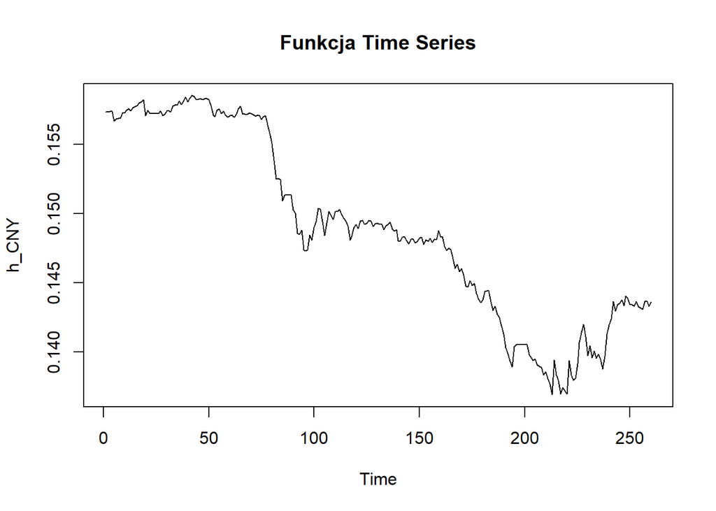

```r
h_CNY <- ts(CNY,frequency=1)
plot(h_CNY, main="Funkcja Time Series")
```

Nie występuje sezonowość.

Dekompozycja Holta-Wintersa.

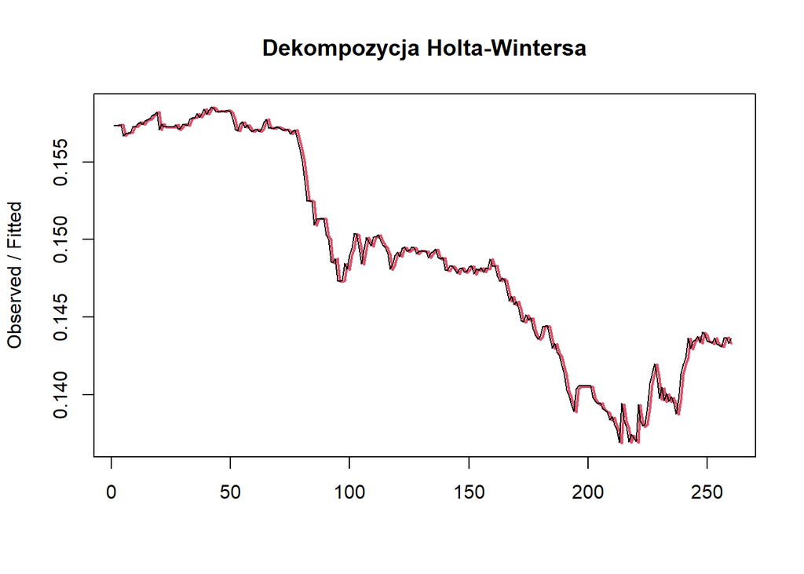

```r
dekompozycja2 <- HoltWinters(h_CNY,gamma = FALSE)
plot(dekompozycja2, lwd=2, main = "Dekompozycja Holta-Wintersa", xlab="")
```

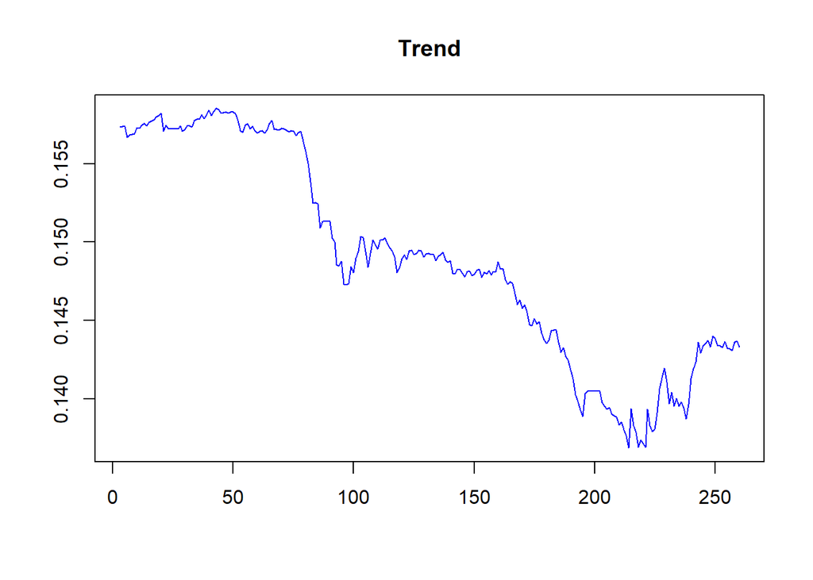

```r
trend2<-dekompozycja2$fitted[,1]
plot(trend2, col="blue", xlab=" ", ylab=" ", main="Trend")
```

## Predykcja

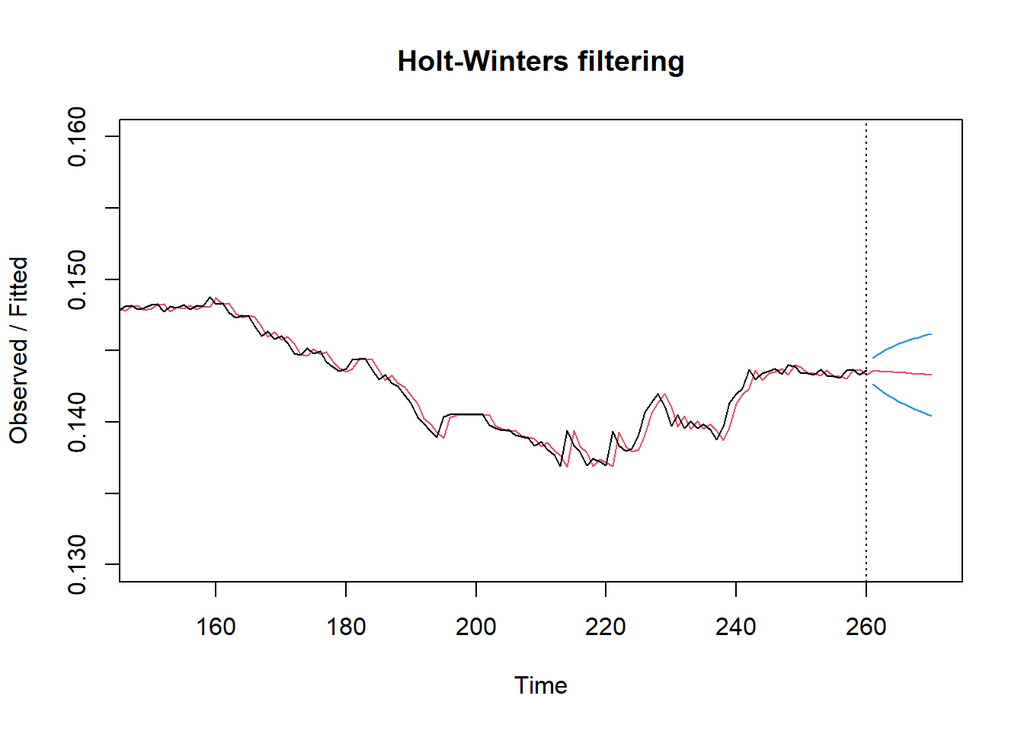

```r
p2 <- predict(dekompozycja2, n.ahead = 10, prediction.interval = TRUE, level = 0.9)

plot(dekompozycja2, p2, xlim = c(150,270), ylim = c(0.130,0.160))
```

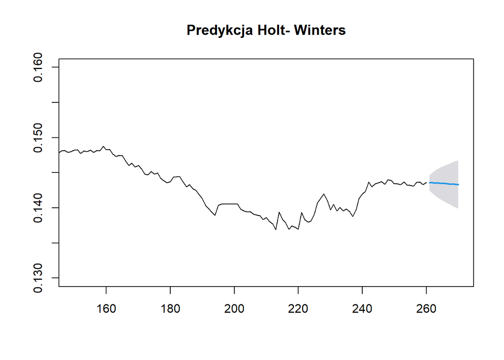

```r
plot(forecast(dekompozycja2, level = c(95), h=10),xlim = c(150,270), ylim = c(0.130,0.160), main = "Predykcja Holt- Winters")
```